# Investigation of two weeks worth of mean response times: Scenario 1

### Figure A

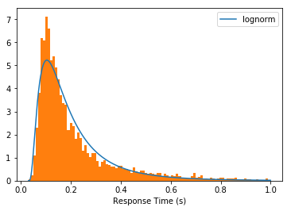

```python
mrt = df[df['mean_response_time'] < 1]
weights = weight_mean_response_times(mrt)

# sub_sample = np.random.choice(restored_no_outliers, 10000)
sub_sample = np.random.choice(mrt['mean_response_time'], 10000, p=weights)
linspace = np.linspace(sub_sample.min(),
                       sub_sample.max(),
                       len(sub_sample))

fit_alpha, fit_loc, fit_beta = st.lognorm.fit(sub_sample)
fitted_lognorm = st.lognorm.freeze(fit_alpha, fit_loc, fit_beta)

fit = fitted_lognorm.pdf(linspace)
plt.plot(linspace, fit, label='lognorm')
plt.hist(sub_sample, normed=True, bins=100)
plt.xlabel('Response Time (s)')
plt.legend(loc='best');
plt.show();
```

### 99% Distribution of Data in time domain

```python
def plot_proba(one, title=None, upper_bound=.995, lower_bound=.005):
    plt.plot(one.index, pd.ewma(one['mean_response_time'], halflife=1000))
    plt.hlines(fitted_lognorm.ppf(upper_bound),
               one.index.min(),
               one.index.max())
    plt.hlines(fitted_lognorm.ppf(lower_bound),
               one.index.min(),
               one.index.max())
    plt.fill_between(one.index, fitted_lognorm.ppf(upper_bound),
                     fitted_lognorm.ppf(lower_bound),
                     label='{:.0f}% of data'.format((upper_bound - lower_bound)*100),
                     alpha=.1)
    plt.legend(loc='best')
    plt.ylim((0, 5))
    plt.ylabel('Response Time')
    plt.xlabel('Time (s)')
    plt.title(title)
```

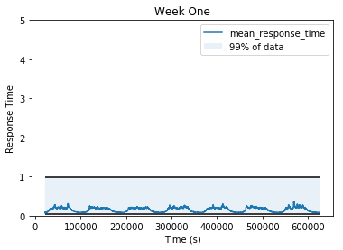

```python
plot_proba(one, 'Week One')
```

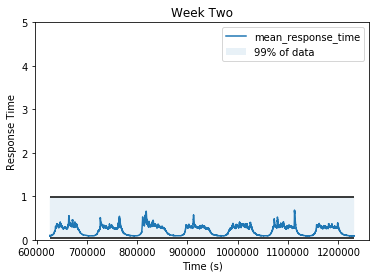

```python
plot_proba(two, 'Week Two')
```

### Figure C

Significantly different behavior between week one and week two excluding outliers.

Bootstrapping the Z-test since I can't remember how to do test statistic for non-normally distributed data.

```
Z_score: -13.09275773748207
p-value: ~0.000000000000000
```

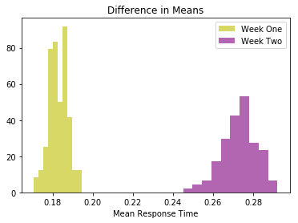

```python
one_restored = df[df.index < 626400]
one_weights = weight_mean_response_times(one_restored)
two_restored = df[df.index >= 626400]
two_weights = weight_mean_response_times(two_restored)

one_means = []
two_means = []
for i in range(100):
    one_means.append(
        np.mean(
            np.random.choice(
                one_restored['mean_response_time'],
                1000,
                p=one_weights)))
    two_means.append(
        np.mean(
            np.random.choice(
                two_restored['mean_response_time'],
                1000,
                p=two_weights)))

one_means, two_means = np.array(one_means), np.array(two_means)

plt.hist(one_means, color='y', bins=10,
         alpha=.6, label='Week One', normed=True)
plt.hist(two_means, color='purple', bins=10,
         alpha=.6, label='Week Two', normed=True)
plt.xlabel('Mean Response Time')
plt.title('Difference in Means')
plt.legend(loc='best');



# bootstrapping z-test by creating samples of mean since this isn't
# normally distributed data.
pooled_std = np.sqrt(((one_means.var() * one_means.shape[0]) +\
        (two_means.var() * two_means.shape[0]))\
    /(one_means.shape[0] + two_means.shape[0]))

z_score = (one_means.mean() - two_means.mean())/pooled_std
p_value = st.norm.cdf(z_score)
print("Z_score: {}".format(z_score))
print("p-value: ~{:.15f}".format(p_value))
```

# Appendix

### Deciding Gamma or LogNormal?

From the samples below, it appears that Lognormal is a reasonable distribution to assume.

Now I can use this distribution to make parametric estimates of probability. (I could have done this empircally too).

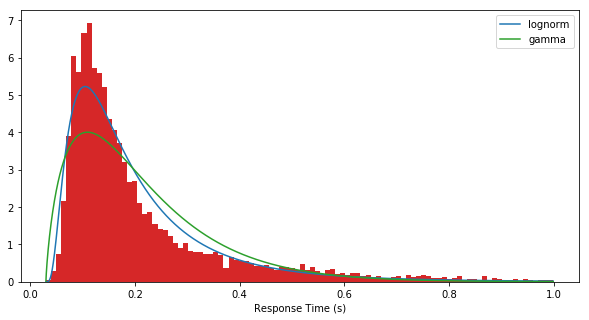

```python
plt.figure(figsize=(10, 5))
sub_sample = np.random.choice(mrt['mean_response_time'], 10000, p=weights)
results = {}
for dist in [st.lognorm, st.gamma]:
    fit_alpha, fit_loc, fit_beta = dist.fit(sub_sample)

    linspace = np.linspace(sub_sample.min(),
                           sub_sample.max(),
                           len(sub_sample))
    fit = dist.pdf(linspace,
                   fit_alpha,
                   fit_loc,
                   fit_beta)
    results[dist.name] = {'alpha': fit_alpha,
                          'loc': fit_loc,
                          'beta': fit_beta}
    plt.plot(linspace, fit, label=dist.name)
    plt.hist(sub_sample, normed=True, bins=100)
    plt.xlabel('Response Time (s)')
    plt.legend(loc='best');
#     plt.show();
```

Log normal looks like the better fit here.